# Tugas MPDW Praktikum 3

Naufal Azizan Rafiansyah

2025-09-15

# Library dan Data

```r
library(dLagM)
library(dynlm)
library(MLmetrics)
library(lmtest)
library(car)
library(readxl)
```

```r
data <- read_excel("C://Users//NAUFAL AZIZAN R//Downloads//NewDelhi_Air_quality.xlsx")
data
```

```
## # A tibble: 72 × 2
##      AQI    CO
##    <dbl> <dbl>
##  1  30.2  199.
##  2  28.2  198.
##  3  26.6  199.
##  4  25    202.
##  5  26    205.
##  6  26    209.
##  7  26    209.
##  8  24    205.
##  9  23    200.
## 10  24    197.
## # ℹ 62 more rows
```

```r
#SPLIT DATA
train<-data[1:54,]
test<-data[55:72,]

#data time series
train.ts<-ts(train)
test.ts<-ts(test)
data.ts<-ts(data)
```

# Model Koyck

## Pemodelan

```r
#MODEL KOYCK
model.koyck <- koyckDlm(x = train$CO, train$AQI)
summary(model.koyck)
```

```
##
## Call:
## "Y ~ (Intercept) + Y.1 + X.t"
##
## Residuals:
##      Min       1Q   Median       3Q      Max
## -2.01328 -0.49464  0.03244  0.58868  2.27048
##
## Coefficients:
##             Estimate Std. Error t value Pr(>|t|)
## (Intercept)  5.28397   10.04682   0.526    0.601
## Y.1          0.90541    0.08492  10.662 1.78e-14 ***
## X.t         -0.01370    0.05734  -0.239    0.812
## ---
## Signif. codes:  0 '***' 0.001 '**' 0.01 '*' 0.05 '.' 0.1 ' ' 1
##
## Residual standard error: 0.9469 on 50 degrees of freedom
## Multiple R-Squared: 0.8177,  Adjusted R-squared: 0.8104
## Wald test: 112.7 on 2 and 50 DF,  p-value: < 2.2e-16
##
## Diagnostic tests:
## NULL
##
##                             alpha        beta       phi
## Geometric coefficients:  55.86447 -0.01369588 0.9054144
```

```r
AIC(model.koyck)
```

```
## [1] 149.5384
```

```r
BIC(model.koyck)
```

```
## [1] 157.4196
```

Berdasarkan hasil tersebut, didapatkan bahwa peubah $y_{t-1}$ memiliki nilai p-value < 0.05, sedangkan peubah $x_t$ memiliki nilai p-value >0.05. Hal ini menunjukkan bahwa peubah $y_{t-1}$ berpengaruh signifikan terhadap peubah $y_t$, sedangkan peubah $x_t$ tidak berpengaruh signifikan terhadap peubah $y_t$ pada taraf signifikansi 5%.

$$\hat{Y_t}=5.284-0.014X_t+0.905Y_{t-1}$$

## Peramalan dan akurasi

```r
fore.koyck <- forecast(model = model.koyck, x = test$CO, h=18)
fore.koyck
```

```
## $forecasts
##  [1] 27.01012 27.01929 27.02759 27.03510 27.06476 27.13733 27.20304 27.28539
##  [9] 27.35995 27.42745 27.48858 27.54392 27.59402 27.61653 27.61406 27.58896
## [17] 27.54337 27.50210
##
## $call
## forecast.koyckDlm(model = model.koyck, x = test$CO, h = 18)
##
## attr(,"class")
## [1] "forecast.koyckDlm" "dLagM"
```

```r
mape.koyck <- MAPE(fore.koyck$forecasts, test$AQI)
mape.koyck #data test
```

```
## [1] 0.2147603
```

```r
#akurasi data training
GoF(model.koyck)
```

```
##              n     MAE         MPE       MAPE      sMAPE     MASE       MSE
## model.koyck 53 0.69404 -0.00111704 0.02563878 0.02556194 1.087051 0.8459109
##                  MRAE    GMRAE
## model.koyck 799356386 12045.11
```

# Distributed Lag

## Pemodelan dengan Lag=2

```r
model.dlm <- dlm(x = train$CO,y = train$AQI , q = 2)
summary(model.dlm)
```

```
##
## Call:
## lm(formula = model.formula, data = design)
##
## Residuals:
##     Min      1Q  Median      3Q     Max
## -4.2685 -0.7228  0.3726  0.9472  3.6075
##
## Coefficients:
##              Estimate Std. Error t value Pr(>|t|)
## (Intercept) -50.95435   14.86849  -3.427  0.00126 **
## x.t           0.46148    0.17209   2.682  0.01002 *
## x.1          -0.05926    0.27832  -0.213  0.83230
## x.2          -0.01508    0.17003  -0.089  0.92969
## ---
## Signif. codes:  0 '***' 0.001 '**' 0.01 '*' 0.05 '.' 0.1 ' ' 1
##
## Residual standard error: 1.67 on 48 degrees of freedom
## Multiple R-squared:  0.4538, Adjusted R-squared:  0.4196
## F-statistic: 13.29 on 3 and 48 DF,  p-value: 1.926e-06
##
## AIC and BIC values for the model:
##        AIC      BIC
## 1 206.7244 216.4806
```

Dari hasil diatas, didapat bahwa $P-value$ dari intercept dan $x_{t}<0.05$. Hal ini menunjukkan bahwa intercept dan $x_{t}$ berpengaruh signifikan terhadap $y$.

$$\hat{Y_t}=-50.954+0.461X_t-0.059X_{t-1}-0.015X_{t-2}$$

## Peramalan dan Akurasi

```r
fore.dlm <- forecast(model = model.dlm, x = test$CO, h=18)
fore.dlm
```

```
## $forecasts
##  [1] 25.80812 25.90701 25.93219 25.93219 25.16202 23.72057 23.94353 23.22370
##  [9] 23.32259 23.34776 23.34776 23.34776 23.34776 24.11793 24.78921 25.43532
## [17] 26.08142 25.95736
##
## $call
## forecast.dlm(model = model.dlm, x = test$CO, h = 18)
##
## attr(,"class")
## [1] "forecast.dlm" "dLagM"
```

```r
mape.dlm <- MAPE(fore.dlm$forecasts, test$AQI)
mape.dlm
```

```
## [1] 0.1051879
```

```r
GoF(model.dlm)
```

```
##            n      MAE          MPE       MAPE     sMAPE    MASE      MSE
## model.dlm 52 1.185068 -0.003428653 0.04382862 0.0431708 1.91261 2.573546
##                 MRAE    GMRAE
## model.dlm 5173280840 37139.41
```

Berdasarkan hasil tersebut, didapatkan bahwa nilai MAPE pada data testing sebesar 10.51% dan pada data training sebesar 4.38%. Hal ini menunjukkan bahwa model Distributed Lag yang dibangun memiliki indikasi overfitting.

## Lag Optimum

```r
#penentuan lag optimum
finiteDLMauto(formula = AQI ~ CO,
              data = data.frame(train), q.min = 1, q.max = 10,
              model.type = "dlm", error.type = "AIC", trace = TRUE)
```

```
##    q - k    MASE      AIC      BIC    GMRAE    MBRAE R.Adj.Sq    Ljung-Box
## 10    10 0.81852 105.9228 129.1173 35689.95  0.48748  0.88833 8.696431e-05
## 9      9 0.82911 108.8921 130.5721 27994.58  0.37193  0.88934 3.250284e-04
## 8      8 1.00196 135.0542 155.1693 26321.36  1.40361  0.82382 1.293720e-02
## 7      7 1.30618 162.8680 181.3695 27820.19 -0.49147  0.70317 2.770183e-03
## 6      6 1.45948 181.2925 198.1333 22563.36  1.40767  0.58048 2.665961e-05
## 5      5 1.69063 194.2696 209.4042 34903.11  2.16190  0.47620 1.062810e-07
## 4      4 1.91254 201.3503 214.7344 47884.35  1.58608  0.42321 7.837120e-09
## 3      3 2.01528 205.6803 217.2712 47175.72 -0.23158  0.40830 3.148107e-10
## 2      2 1.91261 206.7244 216.4806 37139.41  3.31269  0.41964 6.037012e-10
## 1      1 1.90077 210.2894 218.1706 29598.72  0.89193  0.40358 1.524554e-09
```

Berdasarkan output tersebut, didapatkan bahwa lag optimum adalah 10 dengan nilai AIC dan BIC terkecil sebesar 105.9228 dan 129.1173.

```r
model.dlm2 <- dlm(x = train$CO,y = train$AQI , q = 10)
summary(model.dlm2)
```

```
##
## Call:
## lm(formula = model.formula, data = design)
##
## Residuals:
##     Min      1Q  Median      3Q     Max
## -1.0547 -0.3882 -0.1134  0.2706  1.9916
##
## Coefficients:
##               Estimate Std. Error t value Pr(>|t|)
## (Intercept) -47.713832  10.795280  -4.420 0.000106 ***
## x.t           0.447023   0.095632   4.674 5.11e-05 ***
## x.1           0.199436   0.148449   1.343 0.188572
## x.2          -0.160621   0.148320  -1.083 0.286931
## x.3           0.114457   0.155587   0.736 0.467302
## x.4           0.055007   0.156487   0.352 0.727511
## x.5          -0.300889   0.160386  -1.876 0.069798 .
## x.6           0.114867   0.158061   0.727 0.472678
## x.7           0.013956   0.156132   0.089 0.929331
## x.8          -0.144558   0.146606  -0.986 0.331515
## x.9          -0.009137   0.146237  -0.062 0.950567
## x.10          0.044509   0.087297   0.510 0.613651
## ---
## Signif. codes:  0 '***' 0.001 '**' 0.01 '*' 0.05 '.' 0.1 ' ' 1
##
## Residual standard error: 0.7036 on 32 degrees of freedom
## Multiple R-squared:  0.9169, Adjusted R-squared:  0.8883
## F-statistic:  32.1 on 11 and 32 DF,  p-value: 3.633e-14
##
## AIC and BIC values for the model:
##        AIC      BIC
## 1 105.9228 129.1173
```

Dari hasil tersebut terdapat beberapa peubah yang berpengaruh signifikan terhadap taraf nyata 5% yaitu $x_t$. Adapun keseluruhan model yang terbentuk adalah

$$\hat{Y_t}=-47.714+0.447X_t+...+0.0445X_{t-10}$$

## Peramalan dan Akurasi

```r
fore.dlm2 <- forecast(model = model.dlm2, x = test$CO, h=18)
fore.dlm2
```

```
## $forecasts
##  [1] 26.84667 26.08595 26.54572 26.37799 25.29888 23.96084 23.44580 23.02157
##  [9] 22.45613 23.05801 23.60532 23.10682 23.80366 24.85577 25.86759 26.77111
## [17] 27.78821 28.06153
##
## $call
## forecast.dlm(model = model.dlm2, x = test$CO, h = 18)
##
## attr(,"class")
## [1] "forecast.dlm" "dLagM"
```

```r
mape.dlm2 <- MAPE(fore.dlm2$forecasts, test$AQI)
mape.dlm2
```

```
## [1] 0.102997
```

```r
GoF(model.dlm2)
```

```
##             n       MAE           MPE       MAPE      sMAPE      MASE       MSE
## model.dlm2 44 0.4568498 -0.0003895979 0.01638823 0.01643764 0.8185225 0.3600726
##                  MRAE    GMRAE
## model.dlm2 2578373243 35689.95
```

Berdasarkan hasil tersebut, didapatkan bahwa nilai MAPE pada data testing sebesar 10.29% dan pada data training sebesar 1.64%. Hal ini bisa menunjukkan bahwa model Distributed Lag dengan lag optimum yang dibangun teindikasi overfitting.

# Model AutoRegressive

## Pemodelan

```r
model.ardl <- ardlDlm(formula = AQI ~ CO,
                         data = train,p = 1 , q = 1)
summary(model.ardl)
```

```
##
## Time series regression with "ts" data:
## Start = 2, End = 54
##
## Call:
## dynlm(formula = as.formula(model.text), data = data)
##
## Residuals:
##      Min       1Q   Median       3Q      Max
## -2.29095 -0.41937  0.08335  0.44579  1.87491
##
## Coefficients:
##             Estimate Std. Error t value Pr(>|t|)
## (Intercept) -3.91203    7.61604  -0.514  0.60980
## CO.t         0.23326    0.06963   3.350  0.00156 **
## CO.1        -0.19286    0.06772  -2.848  0.00641 **
## AQI.1        0.84215    0.07000  12.031 3.07e-16 ***
## ---
## Signif. codes:  0 '***' 0.001 '**' 0.01 '*' 0.05 '.' 0.1 ' ' 1
##
## Residual standard error: 0.8533 on 49 degrees of freedom
## Multiple R-squared:  0.855,  Adjusted R-squared:  0.8461
## F-statistic: 96.28 on 3 and 49 DF,  p-value: < 2.2e-16
```

```r
AIC(model.ardl)
```

```
## [1] 139.4287
```

```r
BIC(model.ardl)
```

```
## [1] 149.2801
```

Hasil di atas menunjukkan bahwa peubah $x_t$, $x_{t-1}$, dan $y_{t-1}$ memiliki nilai p-value < 0.05. Hal ini menunjukkan bahwa ketiga peubah tersebut berpengaruh signifikan terhadap peubah $y_t$ pada taraf signifikansi 5%.

$$\hat{Y}=-3.912+0.233X_t-0.193X_{t-1}+0.842Y_{t-1}$$

## Peramalan dan Akurasi

```r
fore.ardl <- forecast(model = model.ardl, x = test$CO, h=18)
fore.ardl
```

```
## $forecasts
##  [1] 26.52737 26.45120 26.38706 26.33304 25.89826 25.07540 25.02616 24.59540
##  [9] 24.55451 24.52007 24.49106 24.46663 24.44606 24.81803 25.19870 25.58671
## [17] 25.98089 25.99098
##
## $call
## forecast.ardlDlm(model = model.ardl, x = test$CO, h = 18)
##
## attr(,"class")
## [1] "forecast.ardlDlm" "dLagM"
```

```r
mape.ardl <- MAPE(fore.ardl$forecasts, test$AQI)
mape.ardl #data test
```

```
## [1] 0.1371951
```

```r
GoF(model.ardl)
```

```
##             n       MAE           MPE       MAPE      sMAPE      MASE       MSE
## model.ardl 53 0.6235591 -0.0008720353 0.02292579 0.02285313 0.9766588 0.6731234
##                  MRAE    GMRAE
## model.ardl 1356611649 13796.29
```

Berdasarkan hasil tersebut, didapatkan bahwa nilai MAPE pada data training sebesar 2.293% dan pada data testing sebesar 13.719%. Hal ini menunjukkan bahwa model Autoregressive yang dibangun memiliki indikasi overfitting.

## Lag Optimum

```r
#penentuan lag optimum
model.ardl.opt <- ardlBoundOrders(data = data.frame(data), ic = "AIC",
                                  formula = AQI ~ CO )
model.ardl.opt
```

```
## $p
##   CO
## 1 15
##
## $q
## [1] 6
##
## $Stat.table
##           q = 1    q = 2    q = 3    q = 4    q = 5    q = 6    q = 7    q = 8
## p = 1  168.2819 166.2651 161.6607 157.9799 154.9460 151.9007 142.2749 141.7655
## p = 2  164.8473 163.3331 156.4568 151.0675 150.6558 148.6743 140.6526 141.4722
## p = 3  160.5057 160.5057 158.4568 152.1418 151.9442 149.7779 142.4972 143.2945
## p = 4  155.5034 157.0582 157.0582 153.7779 152.8901 150.8933 144.4972 145.2908
## p = 5  146.4334 147.6417 148.8275 148.8275 146.8885 146.7953 144.1138 145.0288
## p = 6  139.0372 140.7460 142.7230 143.5938 143.5938 144.1934 138.5749 137.9094
## p = 7  140.9979 142.8013 142.6491 141.1302 139.4065 139.4065 140.1131 137.9821
## p = 8  138.7038 138.4923 138.9648 135.5878 135.4907 137.0041 137.0041 138.2546
## p = 9  131.1103 131.5073 133.4716 131.8017 133.3762 134.6431 136.6223 136.6223
## p = 10 127.4866 128.4487 130.4390 130.6004 132.5984 131.8950 133.7767 135.0119
## p = 11 127.6469 128.5046 130.5013 129.8532 131.7773 128.1875 129.6869 131.2037
## p = 12 127.6711 127.4897 129.1757 129.1393 130.9412 129.2049 130.5135 132.0888
## p = 13 127.1372 127.2852 129.1244 129.2587 131.2254 129.8983 131.5868 132.7144
## p = 14 124.1624 124.8474 126.6710 124.1665 124.7897 122.6937 123.9309 125.4630
## p = 15 122.7462 123.0762 124.8446 122.7514 122.5267 121.7055 122.6973 124.5513
##           q = 9   q = 10   q = 11   q = 12   q = 13   q = 14   q = 15
## p = 1  137.6136 134.5537 134.3595 133.8624 132.4862 126.1388 127.1749
## p = 2  137.6932 136.3732 136.0768 135.3172 133.9918 127.5516 128.6567
## p = 3  139.6931 138.3709 138.0742 137.1511 135.7321 129.0672 130.0955
## p = 4  141.6927 140.2948 140.0211 139.0491 137.5738 130.4145 131.5771
## p = 5  140.0291 138.2008 139.4185 138.7488 135.7582 124.1257 125.3936
## p = 6  136.3957 135.9295 137.1350 136.3849 132.5901 124.2831 125.9430
## p = 7  137.6802 137.6837 138.8278 138.0075 134.3664 126.0066 127.6530
## p = 8  136.6303 134.5083 135.7606 135.3003 132.2279 124.6417 126.0605
## p = 9  138.5702 136.4569 137.7360 137.2816 134.2170 126.5949 127.6740
## p = 10 135.0119 137.0097 138.4844 138.7962 136.1884 128.5944 129.6737
## p = 11 133.1740 133.1740 135.0144 136.6470 134.3021 127.3736 128.3392
## p = 12 133.9481 135.9389 135.9389 137.9254 133.5946 129.1369 130.0157
## p = 13 134.6415 136.5655 138.5652 138.5652 133.3119 130.4395 131.3026
## p = 14 127.4116 128.9961 130.2393 130.0985 130.0985 131.9376 133.1505
## p = 15 126.2884 128.2638 128.8698 129.5035 131.1930 131.1930 133.1899
##
## $min.Stat
## [1] 121.7055
```

```r
min_p=c()
for(i in 1:15){
  min_p[i]=min(model.ardl.opt$Stat.table[[i]])
}
q_opt=which(min_p==min(min_p, na.rm = TRUE))
p_opt=which(model.ardl.opt$Stat.table[[q_opt]] ==
              min(model.ardl.opt$Stat.table[[q_opt]], na.rm = TRUE))
data.frame("q_optimum" = q_opt, "p_optimum" = p_opt,
           "AIC"=model.ardl.opt$min.Stat)
```

```
##   q_optimum p_optimum      AIC
## 1         6        15 121.7055
```

Berdasarkan output tersebut, didapatkan bahwa lag optimum adalah p=15 dan q=6 dengan nilai AIC terkecil sebesar 121.7055.

```r
model.ardl2 <- ardlDlm(x = train$CO, y = train$AQI, p = 15 , q = 6)
summary(model.ardl2)
```

```
##
## Time series regression with "ts" data:
## Start = 16, End = 54
##
## Call:
## dynlm(formula = as.formula(model.text), data = data, start = 1)
##
## Residuals:
##      Min       1Q   Median       3Q      Max
## -0.88661 -0.25040 -0.09513  0.24222  1.01266
##
## Coefficients:
##               Estimate Std. Error t value Pr(>|t|)
## (Intercept) -18.329118  30.474263  -0.601  0.55596
## X.t           0.165298   0.124351   1.329  0.20240
## X.1           0.146977   0.155378   0.946  0.35825
## X.2          -0.268240   0.148506  -1.806  0.08972 .
## X.3           0.084196   0.166502   0.506  0.61998
## X.4           0.047271   0.169768   0.278  0.78424
## X.5          -0.304209   0.170662  -1.783  0.09365 .
## X.6           0.397839   0.179790   2.213  0.04180 *
## X.7           0.003290   0.200199   0.016  0.98709
## X.8          -0.220936   0.189545  -1.166  0.26085
## X.9           0.133322   0.194022   0.687  0.50183
## X.10          0.058066   0.199123   0.292  0.77433
## X.11         -0.064993   0.178603  -0.364  0.72070
## X.12         -0.057307   0.160245  -0.358  0.72530
## X.13         -0.000377   0.146342  -0.003  0.99798
## X.14          0.130623   0.140493   0.930  0.36632
## X.15         -0.101867   0.090723  -1.123  0.27807
## Y.1           0.812253   0.263114   3.087  0.00707 **
## Y.2           0.197857   0.335608   0.590  0.56373
## Y.3          -0.147938   0.325986  -0.454  0.65606
## Y.4          -0.065133   0.337081  -0.193  0.84921
## Y.5          -0.110422   0.338645  -0.326  0.74860
## Y.6          -0.109345   0.237921  -0.460  0.65200
## ---
## Signif. codes:  0 '***' 0.001 '**' 0.01 '*' 0.05 '.' 0.1 ' ' 1
##
## Residual standard error: 0.6054 on 16 degrees of freedom
## Multiple R-squared:  0.9669, Adjusted R-squared:  0.9213
## F-statistic: 21.22 on 22 and 16 DF,  p-value: 4.723e-08
```

Berdasarkan hasil tersebut terdapat beberapa peubah yang berpengaruh signifikan terhadap taraf nyata 5% yaitu $x_{t-6}$ dan $y_{t-1}$.

$$\hat{Y}=-18.329+0.165X_t+0.147X_{t-1}+.....-0.109Y_{t-6}$$

# Perbandingan Model

```r
akurasi <- matrix(c(mape.koyck, mape.dlm, mape.dlm2, mape.ardl))
row.names(akurasi)<- c("Koyck","DLM 1","DLM 2","Autoregressive")
colnames(akurasi) <- c("MAPE")
akurasi
```

```
##                     MAPE
## Koyck          0.2147603
## DLM 1          0.1051879
## DLM 2          0.1029970
## Autoregressive 0.1371951
```

Berdasarkan nilai MAPE, model yang paling optimum adalah model DLM2 dengan nilai MAPE terkecil sebesar 10.2997%.

# Plot

```r
length(test$CO)
```

```
## [1] 18
```

```r
length(test$AQI)
```

```
## [1] 18
```

```r
str(fore.koyck)
```

```
## List of 2
##  $ forecasts: num [1:18(1d)] 27 27 27 27 27.1 ...
##  $ call     : language forecast.koyckDlm(model = model.koyck, x = test$CO, h = 18)
##  - attr(*, "class")= chr [1:2] "forecast.koyckDlm" "dLagM"
```

```r
str(fore.dlm)
```

```
## List of 2
##  $ forecasts: num [1:18(1d)] 25.8 25.9 25.9 25.9 25.2 ...
##  $ call     : language forecast.dlm(model = model.dlm, x = test$CO, h = 18)
##  - attr(*, "class")= chr [1:2] "forecast.dlm" "dLagM"
```

```r
str(fore.dlm2)
```

```
## List of 2
##  $ forecasts: num [1:18(1d)] 26.8 26.1 26.5 26.4 25.3 ...
##  $ call     : language forecast.dlm(model = model.dlm2, x = test$CO, h = 18)
##  - attr(*, "class")= chr [1:2] "forecast.dlm" "dLagM"
```

```r
str(fore.ardl)
```

```
## List of 2
##  $ forecasts: num [1:18(1d)] 26.5 26.5 26.4 26.3 25.9 ...
##  $ call     : language forecast.ardlDlm(model = model.ardl, x = test$CO, h = 18)
##  - attr(*, "class")= chr [1:2] "forecast.ardlDlm" "dLagM"
```

```r
head(fore.koyck$forecasts)
```

```
## [1] 27.01012 27.01929 27.02759 27.03510 27.06476 27.13733
```

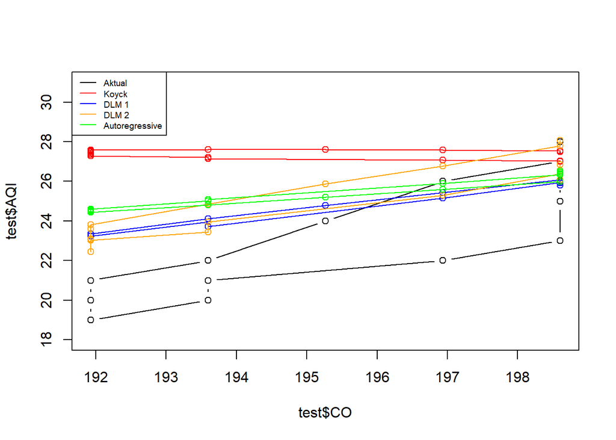

```r
par(mfrow=c(1,1))  # atur layout grafik tunggal

# plot data aktual
plot(test$CO, test$AQI, type="b", col="black", ylim=c(18,31))

# tambahkan garis ramalan dari masing-masing model
points(test$CO, fore.koyck$forecasts, col="red");   lines(test$CO, fore.koyck$forecasts, col="red")
points(test$CO, fore.dlm$forecasts, col="blue");    lines(test$CO, fore.dlm$forecasts, col="blue")
points(test$CO, fore.dlm2$forecasts, col="orange"); lines(test$CO, fore.dlm2$forecasts, col="orange")
points(test$CO, fore.ardl$forecasts, col="green");  lines(test$CO, fore.ardl$forecasts, col="green")

# legenda model
legend("topleft",
       c("Aktual", "Koyck","DLM 1","DLM 2", "Autoregressive"),
       lty=1, col=c("black","red","blue","orange","green"), cex=0.6)
```

Berdasarkan plot diatas, dapat dilihat bahwa model DLM1 dan DLM2 memiliki pola yang paling mendekati data aktual dibandingkan dengan model lainnya. Hal ini sesuai dengan hasil perhitungan MAPE yang menunjukkan bahwa model DLM2 memiliki nilai MAPE terkecil, diikuti oleh model DLM1. Model Koyck dan Autoregressive memiliki pola yang kurang mendekati data aktual, yang juga tercermin dari nilai MAPE yang lebih tinggi dibandingkan dengan model DLM.